# Player exploratory Analysis

## The Premier League, is the top level of the English football league system. Contested by 20 clubs, it operates on a system of promotion and relegation with the English Football League.

## The Premier League is the most-watched sports league in the world, broadcast in 212 territories to 643 million homes and a potential TV audience of 4.7 billion people.

## This dataset consisits of the 974 players which participated in the 2019-2020 season

## Link - https://www.kaggle.com/krishanthbarkav/english-premier-leagueepl-player-statistics?select=pl_19-20.csv

### Load packages if any using library(packagename)

```r
library(zoo)
library(dplyr)
library(writexl)
library(magrittr)
library(GGally)
```

## Load data

```r
d <- read.csv("C:/Users/pc/Downloads/IOT/HPC FINALE/pl_19-20.csv")
str(d)
```

```
## 'data.frame':    974 obs. of  54 variables:
##  $ X                     : int  0 1 2 3 4 5 6 7 8 9 ...
##  $ Name                  : chr  "Max Aarons " "Abdul Rahman Baba " "Tammy Abraham " "Che Adams " ...
##  $ Position              : chr  "Defender" "Defender" "Forward" "Forward" ...
##  $ Appearances           : int  36 0 34 30 0 0 11 0 0 0 ...
##  $ Clean.sheets          : int  5 0 NA NA NA NA 2 NA NA NA ...
##  $ Goals.conceded        : int  71 0 NA NA NA NA 10 NA NA NA ...
##  $ Tackles               : int  48 0 8 6 0 0 NA 0 0 0 ...
##  $ Tackle.success..      : chr  "63%" "0%" "" "" ...
##  $ Last.man.tackles      : int  0 0 NA NA NA NA NA NA NA NA ...
##  $ Blocked.shots         : int  6 0 14 14 0 0 NA 0 0 0 ...
##  $ Interceptions         : int  37 0 6 2 0 0 NA 0 0 0 ...
##  $ Clearances            : int  73 0 27 9 0 0 NA 0 0 0 ...
##  $ Headed.Clearance      : int  28 0 23 3 0 0 NA 0 0 0 ...
##  $ Clearances.off.line   : int  2 0 NA NA NA NA NA NA NA NA ...
```

[output cut: 40 more lines]

```r
summary(d)
```

```
##        X             Name             Position          Appearances
##  Min.   :  0.0   Length:974         Length:974         Min.   : 0.00
##  1st Qu.:243.2   Class :character   Class :character   1st Qu.: 0.00
##  Median :486.5   Mode  :character   Mode  :character   Median : 0.00
##  Mean   :486.5                                         Mean   :10.14
##  3rd Qu.:729.8                                         3rd Qu.:21.00
##  Max.   :973.0                                         Max.   :38.00
##
##   Clean.sheets    Goals.conceded     Tackles       Tackle.success..
##  Min.   : 0.000   Min.   : 0.00   Min.   :  0.00   Length:974
##  1st Qu.: 0.000   1st Qu.: 0.00   1st Qu.:  0.00   Class :character
##  Median : 0.000   Median : 0.00   Median :  0.00   Mode  :character
##  Mean   : 2.099   Mean   :11.41   Mean   : 13.44
##  3rd Qu.: 3.000   3rd Qu.:21.00   3rd Qu.: 22.00
##  Max.   :16.000   Max.   :71.00   Max.   :129.00
##  NA's   :560      NA's   :560     NA's   :109
##  Last.man.tackles Blocked.shots    Interceptions      Clearances
##  Min.   :0.0000   Min.   : 0.000   Min.   : 0.000   Min.   :  0.00
##  1st Qu.:0.0000   1st Qu.: 0.000   1st Qu.: 0.000   1st Qu.:  0.00
##  Median :0.0000   Median : 0.000   Median : 0.000   Median :  0.00
##  Mean   :0.1049   Mean   : 2.753   Mean   : 8.853   Mean   : 15.75
##  3rd Qu.:0.0000   3rd Qu.: 3.000   3rd Qu.:14.000   3rd Qu.: 16.00
##  Max.   :3.0000   Max.   :37.000   Max.   :84.000   Max.   :200.00
##  NA's   :669      NA's   :109      NA's   :109      NA's   :109
##  Headed.Clearance  Clearances.off.line   Recoveries       Duels.won
##  Min.   :  0.000   Min.   :0.0000      Min.   :  0.00   Min.   :  0.00
##  1st Qu.:  0.000   1st Qu.:0.0000      1st Qu.:  0.00   1st Qu.:  0.00
##  Median :  0.000   Median :0.0000      Median :  1.00   Median :  0.00
##  Mean   :  8.138   Mean   :0.0852      Mean   : 48.32   Mean   : 45.72
##  3rd Qu.:  8.000   3rd Qu.:0.0000      3rd Qu.: 82.00   3rd Qu.: 85.00
##  Max.   :111.000   Max.   :3.0000      Max.   :326.00   Max.   :307.00
##  NA's   :109       NA's   :669         NA's   :317      NA's   :317
##    Duels.lost     Successful.50.50s Aerial.battles.won Aerial.battles.lost
##  Min.   :  0.00   Min.   :  0.000   Min.   :  0.00     Min.   :  0.00
##  1st Qu.:  0.00   1st Qu.:  0.000   1st Qu.:  0.00     1st Qu.:  0.00
##  Median :  1.00   Median :  0.000   Median :  0.00     Median :  0.00
##  Mean   : 40.96   Mean   :  7.274   Mean   : 15.78     Mean   : 13.07
##  3rd Qu.: 77.00   3rd Qu.:  9.000   3rd Qu.: 18.00     3rd Qu.: 21.00
##  Max.   :286.00   Max.   :102.000   Max.   :198.00     Max.   :109.00
##  NA's   :317      NA's   :317       NA's   :317        NA's   :317
```

[output cut: 57 more lines]

```
##  Min.   : 0.000   Min.   : 0.000   Min.   : 0.000   Min.   : 0.000
##  1st Qu.: 0.000   1st Qu.: 0.000   1st Qu.: 0.000   1st Qu.: 0.000
##  Median : 0.000   Median : 0.000   Median : 0.000   Median : 0.000
##  Mean   : 2.239   Mean   : 3.266   Mean   : 1.339   Mean   : 2.083
##  3rd Qu.: 1.000   3rd Qu.: 0.000   3rd Qu.: 0.000   3rd Qu.: 1.000
##  Max.   :22.000   Max.   :46.000   Max.   :12.000   Max.   :20.000
##  NA's   :865      NA's   :865      NA's   :865      NA's   :865
##    Throw.outs       Goal.Kicks
##  Min.   :  0.00   Min.   :  0.00
##  1st Qu.:  0.00   1st Qu.:  0.00
##  Median :  0.00   Median :  0.00
##  Mean   : 29.08   Mean   : 47.05
##  3rd Qu.: 11.00   3rd Qu.: 28.00
##  Max.   :255.00   Max.   :340.00
##  NA's   :865      NA's   :865
```

```r
head(d)
```

```
##   X               Name   Position Appearances Clean.sheets Goals.conceded
## 1 0        Max Aarons    Defender          36            5             71
## 2 1 Abdul Rahman Baba    Defender           0            0              0
## 3 2     Tammy Abraham     Forward          34           NA             NA
## 4 3         Che Adams     Forward          30           NA             NA
## 5 4   Dennis Adeniran  Midfielder           0           NA             NA
## 6 5     Albert Adomah  Midfielder           0           NA             NA
##   Tackles Tackle.success.. Last.man.tackles Blocked.shots Interceptions
## 1      48              63%                0             6            37
## 2       0               0%                0             0             0
## 3       8                                NA            14             6
## 4       6                                NA            14             2
## 5       0               0%               NA             0             0
## 6       0               0%               NA             0             0
##   Clearances Headed.Clearance Clearances.off.line Recoveries Duels.won
```

[output cut: 62 more lines]

## Clean the data by including appropriate comments

## checking for NA values

```r
any(is.na(d))
```

```
## [1] TRUE
```

```r
colnames(d)[apply(is.na(d),2,any)]
```

```
##  [1] "Clean.sheets"           "Goals.conceded"         "Tackles"
##  [4] "Last.man.tackles"       "Blocked.shots"          "Interceptions"
##  [7] "Clearances"             "Headed.Clearance"       "Clearances.off.line"
## [10] "Recoveries"             "Duels.won"              "Duels.lost"
## [13] "Successful.50.50s"      "Aerial.battles.won"     "Aerial.battles.lost"
## [16] "Own.goals"              "Errors.leading.to.goal" "Big.chances.created"
## [19] "Crosses"                "Through.balls"          "Accurate.long.balls"
## [22] "Offsides"               "Headed.goals"           "Goals.with.right.foot"
## [25] "Goals.with.left.foot"   "Hit.woodwork"           "Goals.per.match"
## [28] "Penalties.scored"       "Freekicks.scored"       "Shots"
## [31] "Shots.on.target"        "Big.chances.missed"     "Saves"
## [34] "Penalties.saved"        "Punches"                "High.Claims"
## [37] "Catches"                "Sweeper.clearances"     "Throw.outs"
## [40] "Goal.Kicks"
```

```r
sapply(d, function(x) sum(is.na(x)))
```

```
##                      X                   Name               Position
##                      0                      0                      0
##            Appearances           Clean.sheets         Goals.conceded
##                      0                    560                    560
##                Tackles       Tackle.success..       Last.man.tackles
##                    109                      0                    669
##          Blocked.shots          Interceptions             Clearances
##                    109                    109                    109
##       Headed.Clearance    Clearances.off.line             Recoveries
##                    109                    669                    317
##              Duels.won             Duels.lost      Successful.50.50s
##                    317                    317                    317
##     Aerial.battles.won    Aerial.battles.lost              Own.goals
##                    317                    317                    560
## Errors.leading.to.goal                Assists                 Passes
##                    208                      0                      0
##       Passes.per.match    Big.chances.created                Crosses
##                      0                    109                    109
##       Cross.accuracy..          Through.balls    Accurate.long.balls
##                      0                    317                    208
##           Yellow.cards              Red.cards                  Fouls
##                      0                      0                      0
##               Offsides                  Goals           Headed.goals
##                    109                      0                    109
##  Goals.with.right.foot   Goals.with.left.foot           Hit.woodwork
##                    109                    109                    109
##        Goals.per.match       Penalties.scored       Freekicks.scored
##                    414                    414                    414
##                  Shots        Shots.on.target    Shooting.accuracy..
##                    414                    414                      0
##     Big.chances.missed                  Saves        Penalties.saved
##                    414                    865                    865
##                Punches            High.Claims                Catches
##                    865                    865                    865
##     Sweeper.clearances             Throw.outs             Goal.Kicks
##                    865                    865                    865
```

### Hence almost all of the columns have NA values now we will clean them, after typecasting some of the columns for easier cleaning

```r
sapply(d, function(x) typeof(x))
```

```
##                      X                   Name               Position
##              "integer"            "character"            "character"
##            Appearances           Clean.sheets         Goals.conceded
##              "integer"              "integer"              "integer"
##                Tackles       Tackle.success..       Last.man.tackles
##              "integer"            "character"              "integer"
##          Blocked.shots          Interceptions             Clearances
##              "integer"              "integer"              "integer"
##       Headed.Clearance    Clearances.off.line             Recoveries
##              "integer"              "integer"              "integer"
##              Duels.won             Duels.lost      Successful.50.50s
##              "integer"              "integer"              "integer"
##     Aerial.battles.won    Aerial.battles.lost              Own.goals
##              "integer"              "integer"              "integer"
## Errors.leading.to.goal                Assists                 Passes
##              "integer"              "integer"            "character"
##       Passes.per.match    Big.chances.created                Crosses
##               "double"              "integer"              "integer"
##       Cross.accuracy..          Through.balls    Accurate.long.balls
##            "character"              "integer"              "integer"
##           Yellow.cards              Red.cards                  Fouls
##              "integer"              "integer"              "integer"
##               Offsides                  Goals           Headed.goals
##              "integer"              "integer"              "integer"
##  Goals.with.right.foot   Goals.with.left.foot           Hit.woodwork
##              "integer"              "integer"              "integer"
##        Goals.per.match       Penalties.scored       Freekicks.scored
##               "double"              "integer"              "integer"
##                  Shots        Shots.on.target    Shooting.accuracy..
##              "integer"              "integer"            "character"
##     Big.chances.missed                  Saves        Penalties.saved
##              "integer"              "integer"              "integer"
##                Punches            High.Claims                Catches
##              "integer"              "integer"              "integer"
##     Sweeper.clearances             Throw.outs             Goal.Kicks
##              "integer"              "integer"              "integer"
```

```r
ptn<- function(x){
  x_replace_pct<-sub("%", "", x)
  x_as_numeric<-as.numeric(x_replace_pct)/100
  }
dd=d
dd$Tackle.success..=ptn(dd$Tackle.success..)
dd$Passes=as.numeric(dd$Passes)
dd$Cross.accuracy..=ptn(dd$Cross.accuracy..)
dd$Shooting.accuracy..=ptn(dd$Shooting.accuracy..)
```

# data cleaning

### as the columns Saves,penalties saved,punches,high claims,catches,sweeper clearences,throwouts and goalkicks are only for goalkeepers, we can replace the NA values in these columns with 0.

```r
dd$Goal.Kicks[is.na(dd$Goal.Kicks)]=0
dd$Throw.outs[is.na(dd$Throw.outs)]=0
dd$Sweeper.clearances[is.na(dd$Sweeper.clearances)]=0
dd$Catches[is.na(dd$Catches)]=0
dd$High.Claims[is.na(dd$High.Claims)]=0
dd$Punches[is.na(dd$Punches)]=0
dd$Penalties.saved[is.na(dd$Penalties.saved)]=0
dd$Saves[is.na(dd$Saves)]=0
```

## For rest of the columns we will replace with the average of that column

```r
d1=dd
for(i in 4:ncol(d1)){
  d1[is.na(d1[,i]), i] <- round(mean(d1[,i], na.rm = TRUE))
}
```

### Hence the data is finally clean without NA values

```r
any(is.na(d1))
```

```
## [1] FALSE
```

## Statistical Analysis & Inference

## Summary of The cleaned dataset

```r
summary(d1)
```

```
##        X             Name             Position          Appearances
##  Min.   :  0.0   Length:974         Length:974         Min.   : 0.00
##  1st Qu.:243.2   Class :character   Class :character   1st Qu.: 0.00
##  Median :486.5   Mode  :character   Mode  :character   Median : 0.00
##  Mean   :486.5                                         Mean   :10.14
##  3rd Qu.:729.8                                         3rd Qu.:21.00
##  Max.   :973.0                                         Max.   :38.00
##   Clean.sheets    Goals.conceded     Tackles       Tackle.success..
##  Min.   : 0.000   Min.   : 0.00   Min.   :  0.00   Min.   :0.0000
##  1st Qu.: 0.000   1st Qu.: 5.00   1st Qu.:  0.00   1st Qu.:0.0000
##  Median : 2.000   Median :11.00   Median :  3.00   Median :0.0000
##  Mean   : 2.042   Mean   :11.18   Mean   : 13.39   Mean   :0.1891
##  3rd Qu.: 2.000   3rd Qu.:11.00   3rd Qu.: 18.00   3rd Qu.:0.5100
##  Max.   :16.000   Max.   :71.00   Max.   :129.00   Max.   :1.0000
##  Last.man.tackles  Blocked.shots   Interceptions     Clearances
##  Min.   :0.00000   Min.   : 0.00   Min.   : 0.00   Min.   :  0.00
##  1st Qu.:0.00000   1st Qu.: 0.00   1st Qu.: 0.00   1st Qu.:  0.00
##  Median :0.00000   Median : 0.00   Median : 1.00   Median :  1.00
##  Mean   :0.03285   Mean   : 2.78   Mean   : 8.87   Mean   : 15.78
##  3rd Qu.:0.00000   3rd Qu.: 3.00   3rd Qu.:10.00   3rd Qu.: 16.00
##  Max.   :3.00000   Max.   :37.00   Max.   :84.00   Max.   :200.00
##  Headed.Clearance  Clearances.off.line   Recoveries       Duels.won
##  Min.   :  0.000   Min.   :0.00000     Min.   :  0.00   Min.   :  0.00
##  1st Qu.:  0.000   1st Qu.:0.00000     1st Qu.:  0.00   1st Qu.:  0.00
##  Median :  0.000   Median :0.00000     Median : 48.00   Median : 46.00
##  Mean   :  8.122   Mean   :0.02669     Mean   : 48.22   Mean   : 45.81
##  3rd Qu.:  8.000   3rd Qu.:0.00000     3rd Qu.: 48.00   3rd Qu.: 46.00
##  Max.   :111.000   Max.   :3.00000     Max.   :326.00   Max.   :307.00
##    Duels.lost     Successful.50.50s Aerial.battles.won Aerial.battles.lost
##  Min.   :  0.00   Min.   :  0.000   Min.   :  0.00     Min.   :  0.00
##  1st Qu.:  0.00   1st Qu.:  0.000   1st Qu.:  0.00     1st Qu.:  0.00
##  Median : 41.00   Median :  7.000   Median : 16.00     Median : 13.00
##  Mean   : 40.97   Mean   :  7.185   Mean   : 15.85     Mean   : 13.05
##  3rd Qu.: 41.00   3rd Qu.:  7.000   3rd Qu.: 16.00     3rd Qu.: 13.00
##  Max.   :286.00   Max.   :102.000   Max.   :198.00     Max.   :109.00
##    Own.goals       Errors.leading.to.goal    Assists            Passes
##  Min.   :0.00000   Min.   :0.0000         Min.   : 0.0000   Min.   :  0.0
##  1st Qu.:0.00000   1st Qu.:0.0000         1st Qu.: 0.0000   1st Qu.:  0.0
##  Median :0.00000   Median :0.0000         Median : 0.0000   Median :  0.0
##  Mean   :0.02361   Mean   :0.1181         Mean   : 0.6776   Mean   :165.1
```

[output cut: 43 more lines]

```
##  Max.   :1.00000     Max.   :24.000     Max.   :140.000   Max.   :2.0000
##     Punches         High.Claims         Catches        Sweeper.clearances
##  Min.   : 0.0000   Min.   : 0.0000   Min.   : 0.0000   Min.   : 0.0000
##  1st Qu.: 0.0000   1st Qu.: 0.0000   1st Qu.: 0.0000   1st Qu.: 0.0000
##  Median : 0.0000   Median : 0.0000   Median : 0.0000   Median : 0.0000
##  Mean   : 0.2505   Mean   : 0.3655   Mean   : 0.1499   Mean   : 0.2331
##  3rd Qu.: 0.0000   3rd Qu.: 0.0000   3rd Qu.: 0.0000   3rd Qu.: 0.0000
##  Max.   :22.0000   Max.   :46.0000   Max.   :12.0000   Max.   :20.0000
##    Throw.outs        Goal.Kicks
##  Min.   :  0.000   Min.   :  0.000
##  1st Qu.:  0.000   1st Qu.:  0.000
##  Median :  0.000   Median :  0.000
##  Mean   :  3.255   Mean   :  5.266
##  3rd Qu.:  0.000   3rd Qu.:  0.000
##  Max.   :255.000   Max.   :340.000
```

## GEtting the average of each column

```r
sapply(d1[4:46], function(x) mean(x))
```

```
##            Appearances           Clean.sheets         Goals.conceded
##            10.14065708             2.04209446            11.17556468
##                Tackles       Tackle.success..       Last.man.tackles
##            13.39322382             0.18909651             0.03285421
##          Blocked.shots          Interceptions             Clearances
##             2.78028747             8.86960986            15.77926078
##       Headed.Clearance    Clearances.off.line             Recoveries
##             8.12217659             0.02669405            48.21560575
##              Duels.won             Duels.lost      Successful.50.50s
##            45.81211499            40.97330595             7.18480493
##     Aerial.battles.won    Aerial.battles.lost              Own.goals
##            15.85318275            13.04620123             0.02361396
## Errors.leading.to.goal                Assists                 Passes
##             0.11806982             0.67761807           165.14989733
##       Passes.per.match    Big.chances.created                Crosses
##            14.23881930             1.16837782            15.79260780
##       Cross.accuracy..          Through.balls    Accurate.long.balls
##             0.06324435             0.91683778            23.84804928
##           Yellow.cards              Red.cards                  Fouls
##             1.23305955             0.04312115             7.83778234
##               Offsides                  Goals           Headed.goals
##             1.33675565             0.94045175             0.12320329
##  Goals.with.right.foot   Goals.with.left.foot           Hit.woodwork
##             0.65400411             0.27104723             0.21971253
##        Goals.per.match       Penalties.scored       Freekicks.scored
##             0.03081109             0.06673511             0.01950719
##                  Shots        Shots.on.target    Shooting.accuracy..
##            12.98562628             4.78439425             0.08673511
##     Big.chances.missed
##             1.19712526
```

### On average players got atleast one yellow card throughout the season

## Data suited for Goalkeepers

```r
d2=d1 %>% filter(d1$Position=="Goalkeeper")
sapply(d2[47:54], function(x) mean(x))
```

```
##              Saves    Penalties.saved            Punches        High.Claims
##         18.6422018          0.1376147          2.2385321          3.2660550
##            Catches Sweeper.clearances         Throw.outs         Goal.Kicks
##          1.3394495          2.0825688         29.0825688         47.0550459
```

## Getting the Names of the players

```r
sapply(d1[5:54], function(x) d1$Name[which.max(x)])
```

```
##                 Clean.sheets               Goals.conceded
##                   "Ederson "                "Max Aarons "
##                      Tackles             Tackle.success..
##         "Aaron Wan-Bissaka "              "David Brooks "
##             Last.man.tackles                Blocked.shots
##               "Conor Coady "             "Mohamed Salah "
##                Interceptions                   Clearances
##                "Diego Rico "           "James Tarkowski "
##             Headed.Clearance          Clearances.off.line
##           "James Tarkowski "              "Tyrone Mings "
##                   Recoveries                    Duels.won
##    "Pierre-Emile HÃ¸jbjerg "           "James Tarkowski "
##                   Duels.lost            Successful.50.50s
##         "Emiliano BuendÃa "         "Emiliano BuendÃa "
##           Aerial.battles.won          Aerial.battles.lost
##           "James Tarkowski "           "Michail Antonio "
##                    Own.goals       Errors.leading.to.goal
##         "Toby Alderweireld "           "Martin Dubravka "
##                      Assists                       Passes
##           "Kevin De Bruyne "                "John Fleck "
##             Passes.per.match          Big.chances.created
##           "Virgil van Dijk "           "Kevin De Bruyne "
##                      Crosses             Cross.accuracy..
##    "Trent Alexander-Arnold "            "Ibrahim Amadou "
##                Through.balls          Accurate.long.balls
##           "Kevin De Bruyne "                "Ben Foster "
##                 Yellow.cards                    Red.cards
##          "Luka Milivojevic "                "David Luiz "
##                        Fouls                     Offsides
##               "Jordan Ayew "                "Chris Wood "
##                        Goals                 Headed.goals
##               "Jamie Vardy "           "Virgil van Dijk "
##        Goals.with.right.foot         Goals.with.left.foot
## "Pierre-Emerick Aubameyang "             "Mohamed Salah "
##                 Hit.woodwork              Goals.per.match
##           "Kevin De Bruyne "            "Sergio AgÃ¼ero "
##             Penalties.scored             Freekicks.scored
##           "Marcus Rashford "              "Riyad Mahrez "
##                        Shots              Shots.on.target
##             "Mohamed Salah "             "Mohamed Salah "
##          Shooting.accuracy..           Big.chances.missed
##             "Florin Andone "             "Gabriel Jesus "
##                        Saves              Penalties.saved
##           "Martin Dubravka "                  "Tim Krul "
##                      Punches                  High.Claims
##            "Vicente Guaita "                 "Nick Pope "
##                      Catches           Sweeper.clearances
##         "Kasper Schmeichel "                "Ben Foster "
##                   Throw.outs                   Goal.Kicks
##                  "Mat Ryan "           "Martin Dubravka "
```

### Hence we can see the names of the players in each of the category

## Visualization of data & Inference

## Correlation Graph for data suited towards defenders

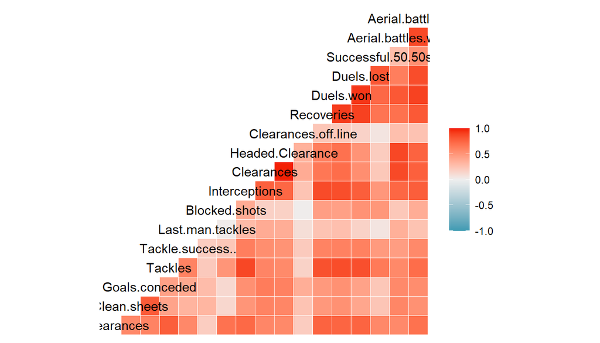

```r
ggcorr(d1[4:20])
```

### Many inferences can be taken from the graph such as

### Most the clearences done by the players were actually headed clearences

### and recoveries were high when the 1 on 1 dual was won by the defender

### And when the aerial battles were won it cleared with the header

## Correlation graph general

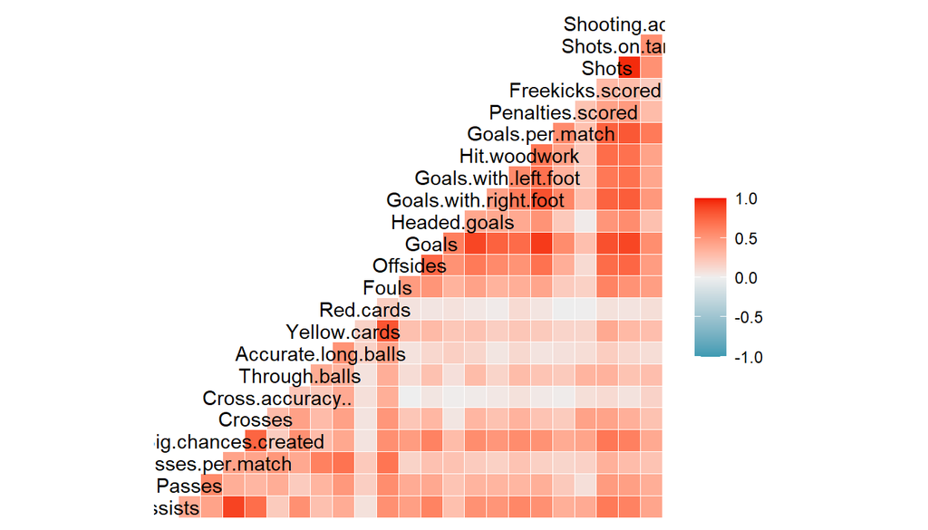

```r
ggcorr(d1[23:45])
```

### Goals hit with the right foot have higher probablity of hitting the woodwork

## correlation graph specific for goalkeepers

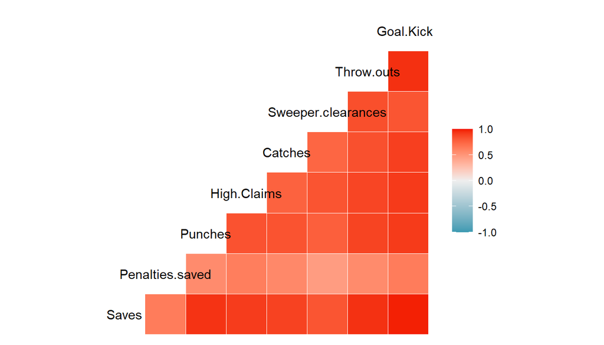

```r
d2=d1 %>% filter(d1$Position=="Goalkeeper")
ggcorr(d2[47:54])
```

### And when he does a high claim he does a throw out

## Which position got the most yellow cards

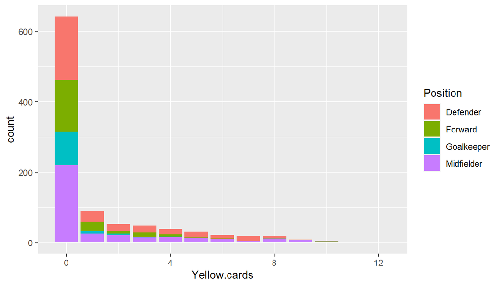

```r
ggplot(d1,aes(x=Yellow.cards,fill=Position))+geom_bar()
```

### Hence as you can see majority of the players didnt get a yellow card

### goal keepers have the least amount of yellow cards

### after 4, majority lies for the either the midfielder or defender

## Which position scored the most goals

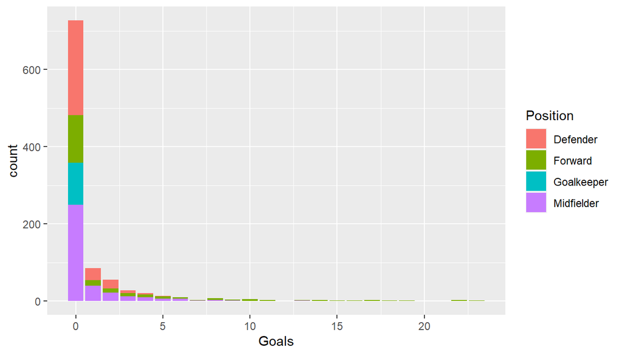

```r
ggplot(d1,aes(x=Goals,fill=Position))+geom_bar()
```

### Majority of the player didnt score any goals but as we progress we can clearly see that only forwards scored more than 10 goals in the 2019-20 season

## Which position Gave the most assists

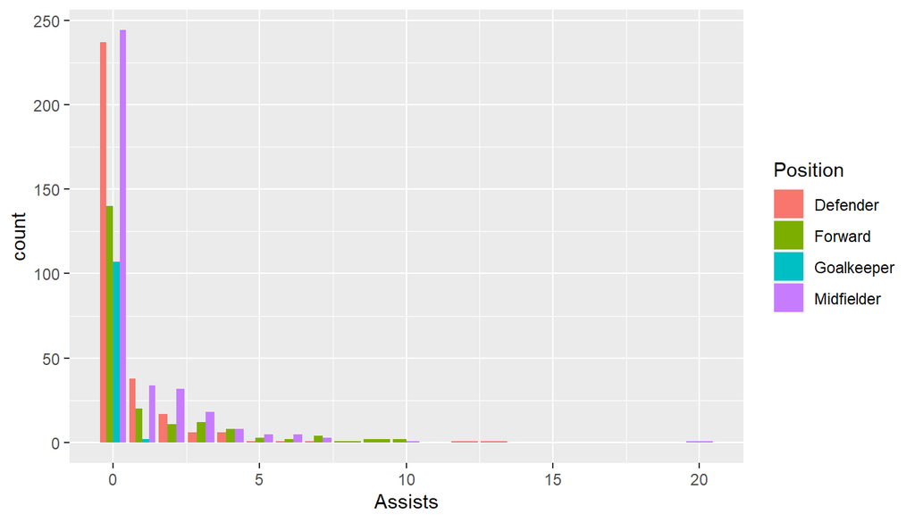

```r
ggplot(d1,aes(x=Assists,fill=Position))+geom_bar( position = "dodge")
```

### We can see that defenders and midfielders gave more assits than forwards who are primarily responsible for finshing and scoring a goal from that assist

## Which position scored the own goals

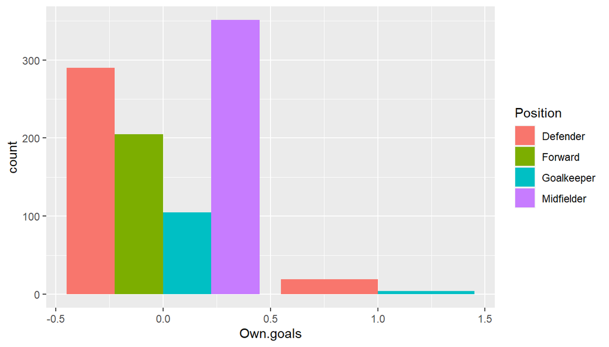

```r
ggplot(d1,aes(x=Own.goals,fill=Position))+geom_bar( position = "dodge")
```

### Hence own Goals were scored either by defenders or goalkeepers

## Distrubution of positions

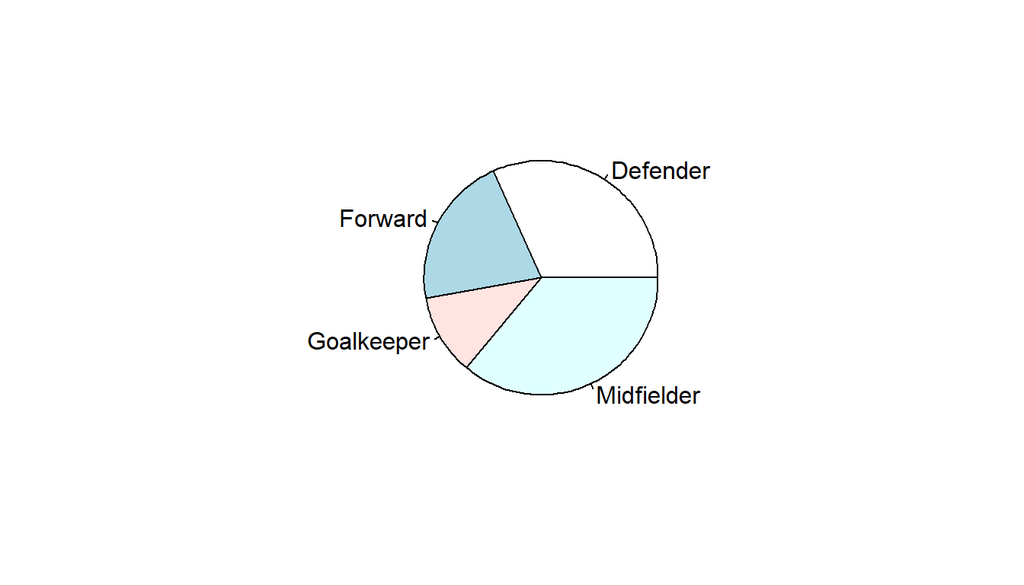

```r
library(plotrix)
pie(table(d1$Position))
```

### Hence majority of players play either in the midfielder or defender position

## Which position had the highest number of appearences

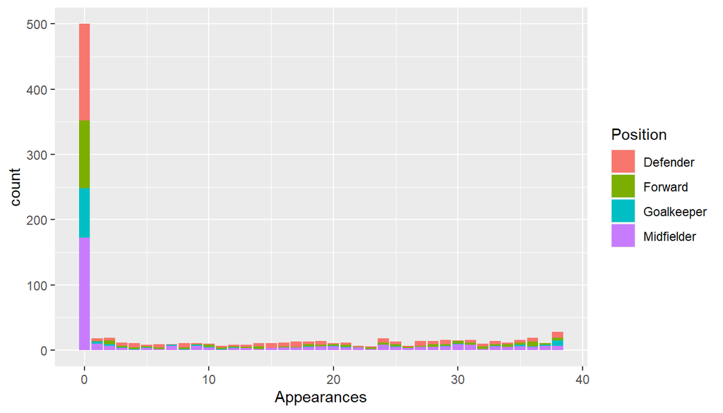

```r
ggplot(d1,aes(x=Appearances,fill=Position))+geom_bar()
```

### This graph shows that majority of the players had 0 appearances meaning coaches only played a certain number of players consistently

## Positions of players who played all 38 games of the season

```r
d4=d1 %>% filter(Appearances==38) %>%
  arrange (desc(Goals))
nrow(d4)
```

```
## [1] 28
```

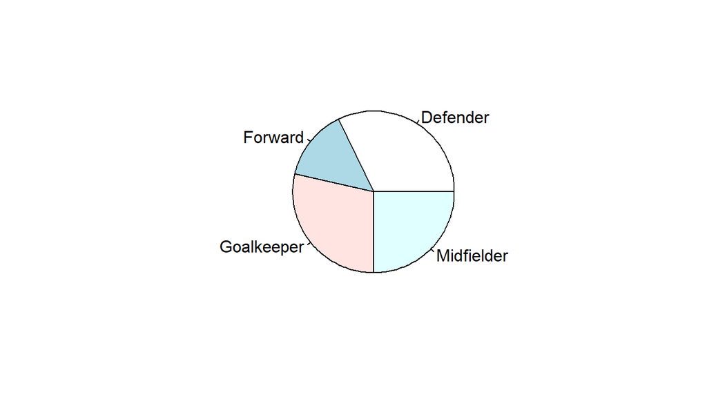

```r
pie(table(d4$Position))
```

## Positions of players who didnt feature in any games

```r
d44=d1 %>% filter(Appearances==0)
nrow(d44)
```

```
## [1] 500
```

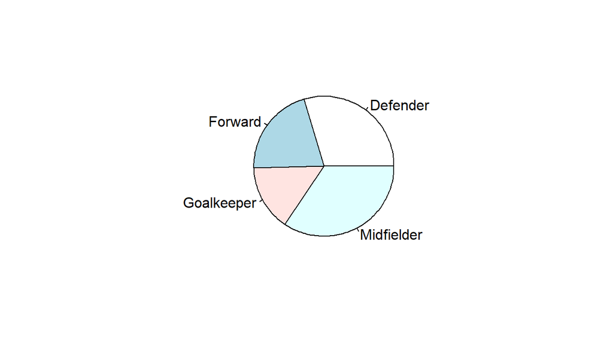

```r
pie(table(d44$Position))
```

### Hence out of the total 974 players in the 20 teams 500 players were never featured in any of the games majority of them being either a midfielder or defender

## Frame any 5 Questions on data manipulation and Corresponding Code & Output

## Finding the best Goalkeeper

### Must have the highes saves, penalties saved, Punches,High claims, and clean sheets

```r
d2=d1 %>% filter(d1$Position=="Goalkeeper")
v1=quantile(d2$Saves,0.85)
v2=quantile(d2$Penalties.saved,0.85)
v3=quantile(d2$Punches,0.85)
v4=quantile(d2$High.Claims,0.85)
v5=quantile(d2$Sweeper.clearances,0.85)
v6=quantile(d2$Clean.sheets,0.90)
dd2=d2 %>% filter(d2$Clean.sheets>v6 & d2$Saves>v1 & d2$Penalties.saved>v2 & d2$Punches>v3 & d2$High.Claims>v4 & d2$Sweeper.clearances>v5) %>% arrange(desc(Clean.sheets))
dd2
```

```
##     X               Name   Position Appearances Clean.sheets Goals.conceded
## 1 719         Nick Pope  Goalkeeper          38           15             50
## 2 801 Kasper Schmeichel  Goalkeeper          38           13             41
## 3 299        Ben Foster  Goalkeeper          38            9             64
##   Tackles Tackle.success.. Last.man.tackles Blocked.shots Interceptions
## 1      13                0                0             3             9
## 2      13                0                0             3             9
## 3      13                0                0             3             9
##   Clearances Headed.Clearance Clearances.off.line Recoveries Duels.won
## 1         16                8                   0         48        46
## 2         16                8                   0         48        46
## 3         16                8                   0         48        46
##   Duels.lost Successful.50.50s Aerial.battles.won Aerial.battles.lost Own.goals
## 1         41                 7                 16                  13         0
## 2         41                 7                 16                  13         0
```

[output cut: 29 more lines]

### Hence The above 3 goalkeepers performed the best with Nick Pope standing out with 15 clean sheets out of 38 appearences and also being in 85% percentile in the columns

## Who was the best attacking player

### Columns of interest are Big.chances created,cross Accuracy,accurate long balls, goals, and shooting accuracy

```r
k1=quantile(d1$Big.chances.created,0.80)
k2=quantile(d1$Cross.accuracy..,0.80)
k3=quantile(d1$Accurate.long.balls,0.80)
k4=quantile(d1$Goals,0.90)
k5=quantile(d1$Shooting.accuracy..,0.90)
k6=quantile(d1$Shots.on.target,0.90)

dd3=d1 %>% filter(d1$Big.chances.created>k1 & d1$Cross.accuracy..>k2 & d1$Accurate.long.balls>k3 & d1$Goals>k4,d1$Shooting.accuracy..>k5 & d1$Shots.on.target>k6) %>% arrange(desc(Goals))
dd3
```

```
##     X               Name   Position Appearances Clean.sheets Goals.conceded
## 1 130   Bruno Fernandes  Midfielder          14            2             11
## 2 925 James Ward-Prowse  Midfielder          38            2             11
##   Tackles Tackle.success.. Last.man.tackles Blocked.shots Interceptions
## 1      22             0.55                0             7            11
## 2      92             0.52                0            14            60
##   Clearances Headed.Clearance Clearances.off.line Recoveries Duels.won
## 1         14                9                   0         67        54
## 2         71               38                   0        249       218
##   Duels.lost Successful.50.50s Aerial.battles.won Aerial.battles.lost Own.goals
## 1         72                15                  3                  11         0
## 2        202                14                 73                  65         0
##   Errors.leading.to.goal Assists Passes Passes.per.match Big.chances.created
## 1                      0       7    777            55.50                   3
## 2                      0       3    165            43.84                   7
##   Crosses Cross.accuracy.. Through.balls Accurate.long.balls Yellow.cards
## 1      75             0.19             8                  46            2
## 2     267             0.22             2                  81            9
##   Red.cards Fouls Offsides Goals Headed.goals Goals.with.right.foot
## 1         0     9        2     8            0                     8
## 2         0    57        0     5            0                     4
##   Goals.with.left.foot Hit.woodwork Goals.per.match Penalties.scored
## 1                    0            3            0.57                4
## 2                    1            1            0.13                1
##   Freekicks.scored Shots Shots.on.target Shooting.accuracy.. Big.chances.missed
## 1                1    44              18                0.41                  4
## 2                2    57              26                0.46                  5
##   Saves Penalties.saved Punches High.Claims Catches Sweeper.clearances
## 1     0               0       0           0       0                  0
## 2     0               0       0           0       0                  0
##   Throw.outs Goal.Kicks
## 1          0          0
## 2          0          0
```

### Hence Bruno fernandes of Manchester united FC was the attacking players being in the top quantirles of suitable variables

## Players who fouls the most

```r
f1=quantile(d1$Yellow.cards,0.95)
f2=quantile(d2$Red.cards,0.95)
f4=quantile(d2$Fouls,0.95)
dd4= d1 %>% filter(d1$Yellow.cards>f1 & d1$Red.cards>f2 & d1$Fouls>f4) %>% arrange(desc(Fouls))
dd4
```

```
##     X             Name   Position Appearances Clean.sheets Goals.conceded
## 1 782   Romain SaÃ¯ss  Midfielder          33            2             11
## 2 520 Jefferson Lerma  Midfielder          33            2             11
## 3 278     Jonny Evans    Defender          38           11             41
##   Tackles Tackle.success.. Last.man.tackles Blocked.shots Interceptions
## 1      55             0.69                0             5            55
## 2      54             0.59                0             9            57
## 3      48             0.71                0             1            57
##   Clearances Headed.Clearance Clearances.off.line Recoveries Duels.won
## 1        121               66                   0        185       205
## 2         51               29                   0        270       173
## 3        171               84                   0        230       207
##   Duels.lost Successful.50.50s Aerial.battles.won Aerial.battles.lost Own.goals
## 1        132                 7                120                  68         0
## 2        144                26                 57                  51         0
```

[output cut: 29 more lines]

### Hence out of the 3 players Romain Saiis of Wolves FC, was the player who did the most fouls

## who was the best defensive player

```r
q1=quantile(d1$Tackle.success..,0.90)
q2=quantile(d1$Blocked.shots,0.90)
q3=quantile(d1$Duels.won,0.90)
q4=quantile(d1$Aerial.battles.won,0.90)
q5=quantile(d1$Successful.50.50s,0.90)

dd5=d1 %>% filter(Position=="Defender" & d1$Tackle.success..>q1 & d1$Blocked.shots>q2 & d1$Duels.won>q3 & d1$Aerial.battles.won>q4 & d1$Successful.50.50s>q5)

dd5
```

```
##     X         Name Position Appearances Clean.sheets Goals.conceded Tackles
## 1 238 Lucas Digne  Defender          35            7             49      73
##   Tackle.success.. Last.man.tackles Blocked.shots Interceptions Clearances
## 1             0.67                0            15            42         93
##   Headed.Clearance Clearances.off.line Recoveries Duels.won Duels.lost
## 1               47                   0        182       237        167
##   Successful.50.50s Aerial.battles.won Aerial.battles.lost Own.goals
## 1                23                114                  53         1
##   Errors.leading.to.goal Assists Passes Passes.per.match Big.chances.created
## 1                      0       7    165            39.26                   8
##   Crosses Cross.accuracy.. Through.balls Accurate.long.balls Yellow.cards
## 1     270             0.27             2                  64            6
##   Red.cards Fouls Offsides Goals Headed.goals Goals.with.right.foot
## 1         0    43        3     0            0                     0
##   Goals.with.left.foot Hit.woodwork Goals.per.match Penalties.scored
## 1                    0            1               0                0
##   Freekicks.scored Shots Shots.on.target Shooting.accuracy.. Big.chances.missed
## 1                0    13               5                   0                  1
##   Saves Penalties.saved Punches High.Claims Catches Sweeper.clearances
## 1     0               0       0           0       0                  0
##   Throw.outs Goal.Kicks
## 1          0          0
```

### HEnce Lucas digne from everton FC was the best performing Defender

## Which player was a liabilty to the team

```r
w1=quantile(d1$Own.goals,0.90)
w2=quantile(d1$Errors.leading.to.goal,0.90)
w3=quantile(d1$Duels.lost,0.90)

dd6= d1 %>% filter(d1$Own.goals>w1 & d1$Errors.leading.to.goal>w2 & d1$Duels.lost>w3)
dd6
```

```
##    X          Name Position Appearances Clean.sheets Goals.conceded Tackles
## 1 50 Serge Aurier  Defender          33            6             32      93
##   Tackle.success.. Last.man.tackles Blocked.shots Interceptions Clearances
## 1             0.74                0             6            47         84
##   Headed.Clearance Clearances.off.line Recoveries Duels.won Duels.lost
## 1               48                   0        165       224        187
##   Successful.50.50s Aerial.battles.won Aerial.battles.lost Own.goals
## 1                39                 70                  64         1
##   Errors.leading.to.goal Assists Passes Passes.per.match Big.chances.created
## 1                      1       5    165            38.82                   4
##   Crosses Cross.accuracy.. Through.balls Accurate.long.balls Yellow.cards
## 1     137             0.15             0                  33            2
##   Red.cards Fouls Offsides Goals Headed.goals Goals.with.right.foot
## 1         1    41        6     1            0                     0
##   Goals.with.left.foot Hit.woodwork Goals.per.match Penalties.scored
## 1                    1            0               0                0
##   Freekicks.scored Shots Shots.on.target Shooting.accuracy.. Big.chances.missed
## 1                0    13               5                   0                  1
##   Saves Penalties.saved Punches High.Claims Catches Sweeper.clearances
## 1     0               0       0           0       0                  0
##   Throw.outs Goal.Kicks
## 1          0          0
```

### HEnce serge Aurier from Tottenham FC was th player which proved to be a liability to the team